# Week3Assignment

Krishna

2022-11-28

## NYPD Shooting Incident Data (Historic)

Data is list of every shooting incident that occurred in NYC going back to 2006 through the end of the previous calendar year ie 2021. It can be accessed from https://catalog.data.gov/dataset.

Intent is to import data and see if there is any correlation between race of perpetrator and victim and a brief idea of areas of NYC where incidents were recorded.

**Import and clean data**

```r
library(tidyverse)
```

```r
library(dplyr)
library(ggplot2)
library(tidyr)
library(leaflet)

tf <- tempfile()
download.file("https://data.cityofnewyork.us/api/views/833y-fsy8/rows.csv?accessType=DOWNLOAD", tf)
data <- read_csv(tf)
file.remove(tf)
```

```
## [1] TRUE
```

```r
rm(tf)
data <- data %>% select(-INCIDENT_KEY,
                      -LOCATION_DESC,
                      -PRECINCT,
                      -JURISDICTION_CODE)
```

**Summary of data**

```r
summary(data)
```

```
##   OCCUR_DATE         OCCUR_TIME           BORO
##  Length:25596       Length:25596      Length:25596
##  Class :character   Class1:hms        Class :character
##  Mode  :character   Class2:difftime   Mode  :character
##                     Mode  :numeric
##
##
##  STATISTICAL_MURDER_FLAG PERP_AGE_GROUP       PERP_SEX
##  Mode :logical           Length:25596       Length:25596
##  FALSE:20668             Class :character   Class :character
##  TRUE :4928              Mode  :character   Mode  :character
##
##
##
##   PERP_RACE         VIC_AGE_GROUP        VIC_SEX            VIC_RACE
##  Length:25596       Length:25596       Length:25596       Length:25596
##  Class :character   Class :character   Class :character   Class :character
##  Mode  :character   Mode  :character   Mode  :character   Mode  :character
##
##
##
##    X_COORD_CD        Y_COORD_CD        Latitude       Longitude
##  Min.   : 914928   Min.   :125757   Min.   :40.51   Min.   :-74.25
##  1st Qu.:1000011   1st Qu.:182782   1st Qu.:40.67   1st Qu.:-73.94
##  Median :1007715   Median :194038   Median :40.70   Median :-73.92
##  Mean   :1009455   Mean   :207894   Mean   :40.74   Mean   :-73.91
##  3rd Qu.:1016838   3rd Qu.:239429   3rd Qu.:40.82   3rd Qu.:-73.88
##  Max.   :1066815   Max.   :271128   Max.   :40.91   Max.   :-73.70
##    Lon_Lat
##  Length:25596
##  Class :character
##  Mode  :character
##
##
##
```

## Plots

### Shooting incidents according to occurrence time

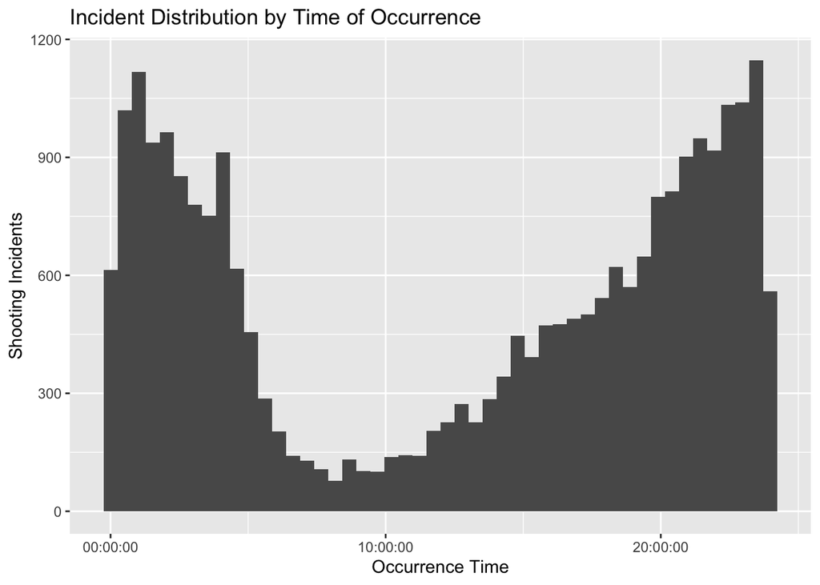

```r
data %>%
  ggplot(aes(OCCUR_TIME)) +
  geom_histogram(bins = 48) +
  xlab("Occurrence Time") +
  ylab("Shooting Incidents") +
  ggtitle("Incident Distribution by Time of Occurrence")
```

### Shooting incidents on a map of NYC by cluster

```r
cluster <- leaflet(data) %>%
  addTiles() %>%
  addMarkers(clusterOptions = markerClusterOptions()) %>%
  setView(-74.00, 40.71, zoom = 10) %>%
  addProviderTiles("CartoDB.VoyagerLabelsUnder")
cluster
```

[interactive chart not shown]

### Shooting incidents by victim race

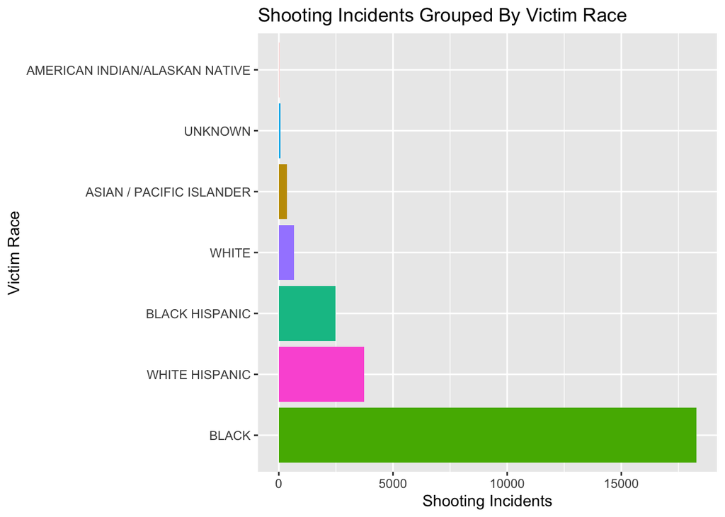

```r
victim_race_incidents <- data %>%
  group_by(VIC_RACE) %>%
  summarize(count = n(),
            prop = count/nrow(data),
            prop_death = mean(STATISTICAL_MURDER_FLAG))

victim_race_incidents %>%
  ggplot(aes(count, y = reorder(VIC_RACE, - count), fill = VIC_RACE)) +
  geom_bar(stat = "identity") +
  ylab("Victim Race") +
  xlab("Shooting Incidents") +
  ggtitle("Shooting Incidents Grouped By Victim Race") +
  theme(legend.position = "none")
```

### Perpetrators grouped by race and age

```r
options(dplyr.summarise.inform = FALSE)
df_non_na_perp<- data %>% filter_at(vars(PERP_RACE,PERP_AGE_GROUP),all_vars(!is.na(.)))
df_non_na_perp<-df_non_na_perp[!df_non_na_perp$PERP_AGE_GROUP %in% c("1020", "940", "224", "UNKNOWN"), ]
perp_count<- df_non_na_perp %>% group_by(PERP_RACE, PERP_AGE_GROUP) %>% summarise(count = n())
perp_count
```

| PERP_RACE | PERP_AGE_GROUP | count |
| --- | --- | --- |
| AMERICAN INDIAN/ALASKAN NATIVE | 18-24 | 1 |
| AMERICAN INDIAN/ALASKAN NATIVE | 25-44 | 1 |
| ASIAN / PACIFIC ISLANDER | <18 | 14 |
| ASIAN / PACIFIC ISLANDER | 18-24 | 41 |
| ASIAN / PACIFIC ISLANDER | 25-44 | 68 |
| ASIAN / PACIFIC ISLANDER | 45-64 | 7 |
| BLACK | <18 | 1079 |
| BLACK | 18-24 | 4191 |
| BLACK | 25-44 | 3780 |
| BLACK | 45-64 | 342 |

[output cut: 21 more lines]

**Plot**

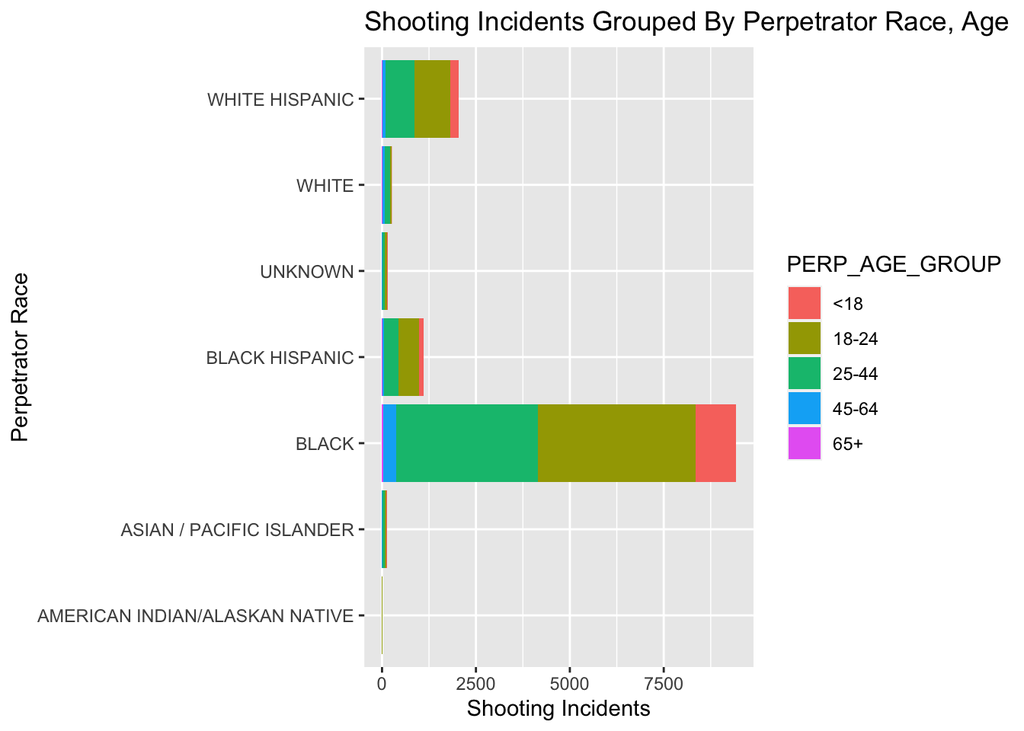

```r
ggplot(perp_count, aes(fill=PERP_AGE_GROUP, x=count, y=PERP_RACE)) +
  geom_bar(position="stack", stat="identity")+
  ylab("Perpetrator Race") +
  xlab("Shooting Incidents") +
  ggtitle("Shooting Incidents Grouped By Perpetrator Race, Age")
```

## Heatmap based on perpetrator and victim race

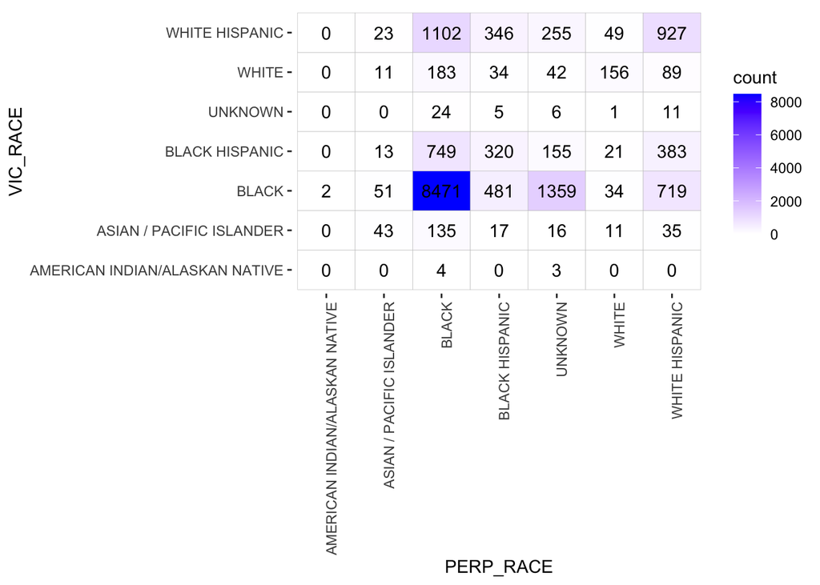

```r
df_non_na_perp_vic<- data %>% filter_at(vars(PERP_RACE,VIC_RACE),all_vars(!is.na(.)))
perp_vic<- df_non_na_perp_vic %>% group_by(PERP_RACE, VIC_RACE) %>% summarise(count = n())
vic_race <- unique(perp_vic$VIC_RACE)
perp_vic<-perp_vic%>%
  complete(VIC_RACE = vic_race, fill=list(count=0))
ggp <- ggplot(perp_vic, aes(PERP_RACE, VIC_RACE)) +    # Create default ggplot2 heatmap
  geom_tile(aes(fill = count), color = "grey")
ggp +                                         # Add values & modify color
  geom_text(aes(label = count)) +
  scale_fill_gradient2(low = "purple", high= "blue")+
  theme(
    panel.background = element_rect(fill = "white"),
    panel.grid = element_line(color = "white"),
    axis.text.x = element_text(angle=90, hjust=1))
```

## Findings

Where perpetrator’s race is known, majority of incidents involve BLACK race. Same is the case with victims as well. Where victim’s race is known, majority of incidents involve BLACK race.

Majority of the incidents happened during 8PM and 5AM.

Where perpetrator’s race and age is known, majority of incidents involve perpetrators aged between 18 and 44.

The data is tidied to remove entries that have partial or unexpected data. While the data is tidied, it is not tampered and we dont have complete details of the real incidents or the way this data was sourced.